# Ne time series modeling

Helene Wagner

# 1. Introduction

## a) Objective

The goal is to identify periods with distinct rates of change in the reconstructed time series of Ne for the GTA.

## b) Mathematical model

We will assume an exponential growth or decay model for Ne (i.e., contant percent gain or loss of Ne per year within a period), where r is the percent change from one year to the next (growth: r > 0, decay: r < 0):

$Ne_t = Ne_0 * (1+r)^t$

Linearize by taking the log on both sides:

$log(Ne_t)= log(Ne_0) + t * log(1+r)$

Thus, when plotting log(Ne) (on the y axis) against time t (on the x-axis), a period with constant rate of change would be characterized by a constant slope of b = log(1+r), where different periods would differ in their slope b due to a different rate of change, r.

## c) Piece-wise regression analysis

Piece-wise regression identifies ranges of t with a constant slope and identifies the breakpoints between them. R package `segmented` requires the user to give an initial, rough estimate of the breakpoints (based on visual analysis), then optimizes the estimates so that the regression lines of two adjacent periods meet at the breakpoint between them. Note that this means that the user determines the number of periods to consider.

[Muggeo, V.M.R. (2008). segmented: An R package to fit regression mModels with broken-line relationships. R News, 8, 20-25.](https://journal.r-project.org/articles/RN-2008-004/RN-2008-004.pdf)

## d) Load packages

```r
library(dplyr)
library(here)
library(segmented)
library(readxl)
```

## e) Data

The data consist of yearly values for Ne reconstructed from the full sample of genotyped individuals of *Asclepias syriaca* through simulation backwards in time with the software Stairway Plot v2 (Liu and Fu 2020).

The following variables will be used:

- Year: time in years before data collection (summer 2018).
- Ne_median: median of estimates across 200 replicate simulations to reconstruct historic Ne.

## f) Import data

```r
Ne_data <- read.delim(here::here("./results/StairwayPlot/mu_1.8e-8/gen_time_2yr/full/full_mmaf0.007813_mut_rate_1.8e-8_2yrs.final.summary")) %>%
  dplyr::select(-c(theta_per_site_median,
                   theta_per_site_2.5.,
                   theta_per_site_97.5.,
                   n_estimation,
                   mutation_per_site)) %>%
  # remove duplicate rows
  distinct(.keep_all = TRUE)
names(Ne_data)
```

```
## [1] "year"      "Ne_median" "Ne_2.5."   "Ne_97.5."  "Ne_12.5."  "Ne_87.5."
```

# 2. Linearize the relationship to visually identify breakpoints

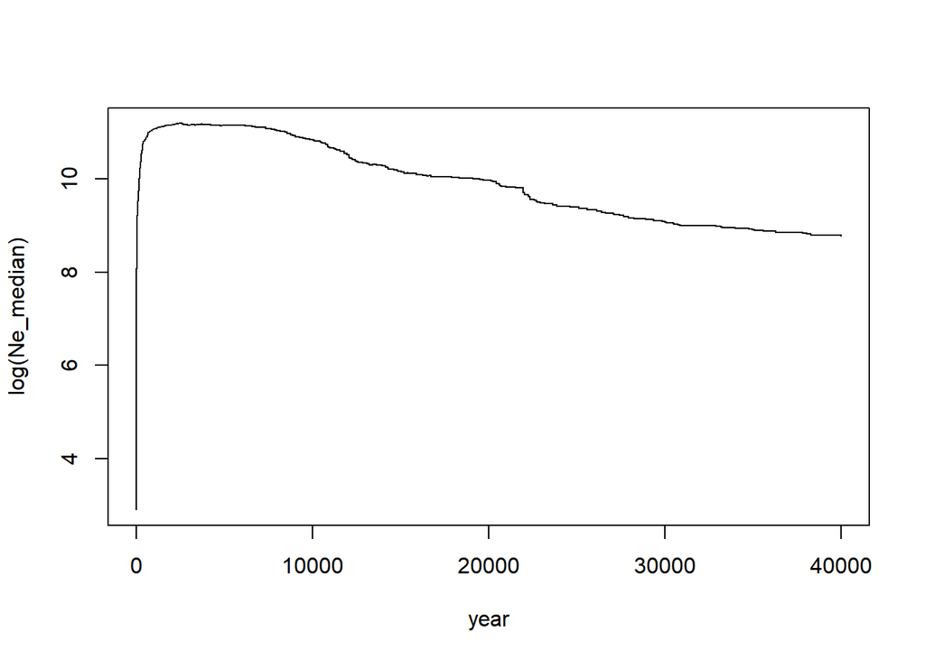

```r
plot(log(Ne_median) ~ year, data=Ne_data %>% filter(year < 40000), type="l")
```

*Interpretation*: Visual identification of breakpoints:

- 30000
- 8000
- 2000 (suggested by model fitting)
- need more resolution for the first 1000 years to identify further breakpoints

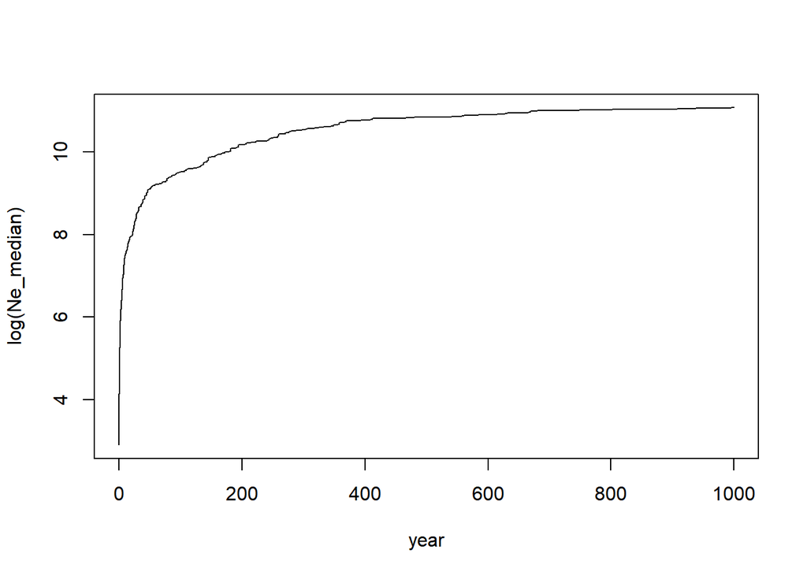

```r
breakpoints <- c(2000, 8000, 30000)
plot(log(Ne_median) ~ year, data=Ne_data %>% filter(year < 1000), type="l")
```

*Interpretation*: Visual identification of additional breakpoints:

- 700 (chosen a bit low to prevent issues later on)
- 400
- 200 (suggested by model fitting)
- need more resolution for the first 100 years to identify further breakpoints

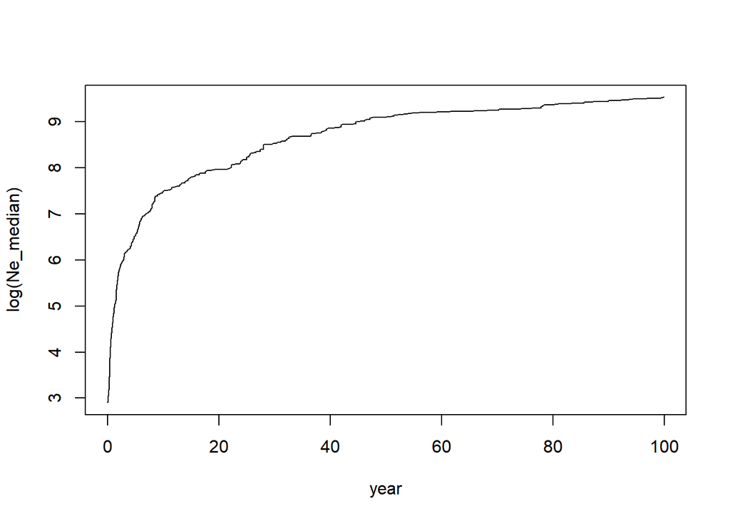

```r
breakpoints <- c(200, 400, 700, breakpoints)
plot(log(Ne_median) ~ year, data=Ne_data %>% filter(year < 100), type="l")
```

*Interpretation*: Visual identification of additional breakpoints:

- 40 (chosen a bit low to prevent issues later on)
- 10
- 2

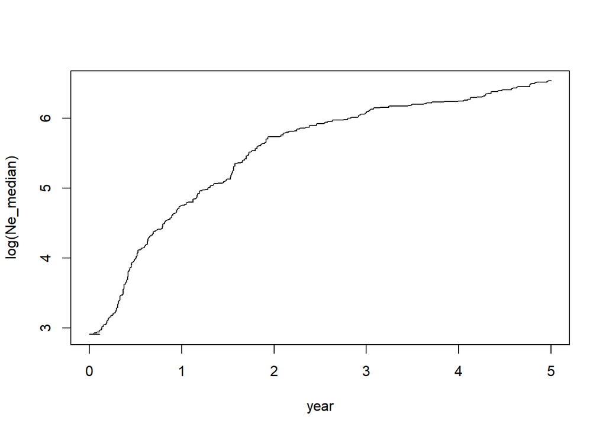

```r
breakpoints <- c(2, 10, 40, breakpoints)
plot(log(Ne_median) ~ year, data=Ne_data %>% filter(year < 5), type="l")
```

# 3. Fit piecewise regression model

Prepare storage of models

```r
Models <- list()
```

## a) Range between 1 - 100 years

Note: When running the model for the entire dataset with all breakpoints, there is an error message that the breakpoints are too close together. Therefore, the analysis will be performed at three temporal scales.

Filter data for period: <100 years

```r
size = 100 # desired size of subsample
period = c(1, 100)
tmp  = Ne_data %>% filter(year < period[2], year > period[1])
factor <- nrow(tmp) %/% size
tmp  = tmp[c(1:nrow(tmp)) %% factor == 0,]
dim(tmp)
```

```
## [1] 100   6
```

```r
Ne_median.lm <- lm(log(Ne_median) ~ year, data = tmp)
Ne_median.seg <- segmented(Ne_median.lm,
                    seg.Z = ~ year,
                    psi = list(year = breakpoints[breakpoints > period[1] & breakpoints < period[2]]))
Models[[1]] <- Ne_median.seg
```

```r
summary(Ne_median.seg)
```

```
##
##  ***Regression Model with Segmented Relationship(s)***
##
## Call:
## segmented.lm(obj = Ne_median.lm, seg.Z = ~year, psi = list(year = breakpoints[breakpoints >
##     period[1] & breakpoints < period[2]]))
##
## Estimated Break-Point(s):
##              Est. St.Err
## psi1.year  2.120  0.027
## psi2.year  8.855  0.130
## psi3.year 41.319  0.845
##
## Meaningful coefficients of the linear terms:
##              Estimate Std. Error t value Pr(>|t|)
## (Intercept)  3.684342   0.035784  102.96   <2e-16 ***
## year         1.020940   0.023993   42.55   <2e-16 ***
## U1.year     -0.784057   0.024337  -32.22       NA
## U2.year     -0.188930   0.004202  -44.96       NA
## U3.year     -0.038704   0.001248  -31.01       NA
## ---
## Signif. codes:  0 '***' 0.001 '**' 0.01 '*' 0.05 '.' 0.1 ' ' 1
##
## Residual standard error: 0.04332 on 92 degrees of freedom
## Multiple R-Squared: 0.9992,  Adjusted R-squared: 0.9991
##
## Boot restarting based on 6 samples. Last fit:
## Convergence attained in 2 iterations (rel. change 4.5408e-11)
```

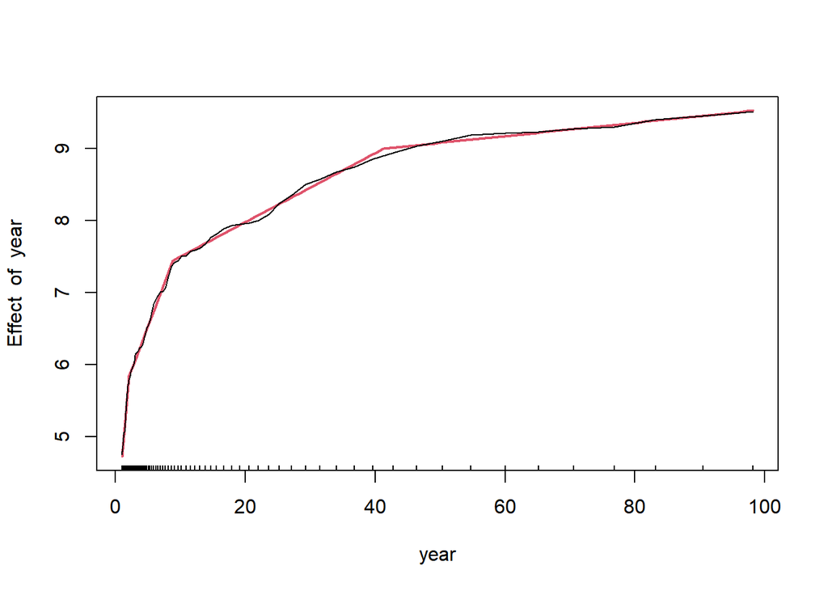

```r
plot(Ne_median.seg)
lines(tmp$year, log(tmp$Ne_median))
```

## b) Range between 100 - 2000 years

Filter and resample data for period

```r
size = 100 # desired size of subsample
period = c(max(Models[[1]]$psi[,2]), 2000)
tmp  = Ne_data %>% filter(year < period[2], year > period[1])
factor <- nrow(tmp) %/% size
tmp  = tmp[c(1:nrow(tmp)) %% factor == 0,]
dim(tmp)
```

```
## [1] 101   6
```

```r
Ne_median.lm <- lm(log(Ne_median) ~ year, data = tmp)
Ne_median.seg <- segmented(Ne_median.lm,
                    seg.Z = ~ year,
                    psi = list(year = breakpoints[breakpoints > period[1] & breakpoints < period[2]]))

Models[[2]] <- Ne_median.seg
```

```r
summary(Ne_median.seg)
```

```
##
##  ***Regression Model with Segmented Relationship(s)***
##
## Call:
## segmented.lm(obj = Ne_median.lm, seg.Z = ~year, psi = list(year = breakpoints[breakpoints >
##     period[1] & breakpoints < period[2]]))
##
## Estimated Break-Point(s):
##               Est. St.Err
## psi1.year 195.658  4.426
## psi2.year 375.771  7.926
## psi3.year 790.127 31.367
##
## Meaningful coefficients of the linear terms:
##               Estimate Std. Error t value Pr(>|t|)
## (Intercept)  8.745e+00  1.143e-02 765.165   <2e-16 ***
## year         7.315e-03  1.037e-04  70.544   <2e-16 ***
## U1.year     -4.069e-03  1.793e-04 -22.686       NA
## U2.year     -2.567e-03  1.574e-04 -16.304       NA
## U3.year     -5.720e-04  5.999e-05  -9.535       NA
## ---
## Signif. codes:  0 '***' 0.001 '**' 0.01 '*' 0.05 '.' 0.1 ' ' 1
##
## Residual standard error: 0.02882 on 93 degrees of freedom
## Multiple R-Squared: 0.9986,  Adjusted R-squared: 0.9985
##
## Boot restarting based on 6 samples. Last fit:
## Convergence attained in 3 iterations (rel. change 2.0294e-12)
```

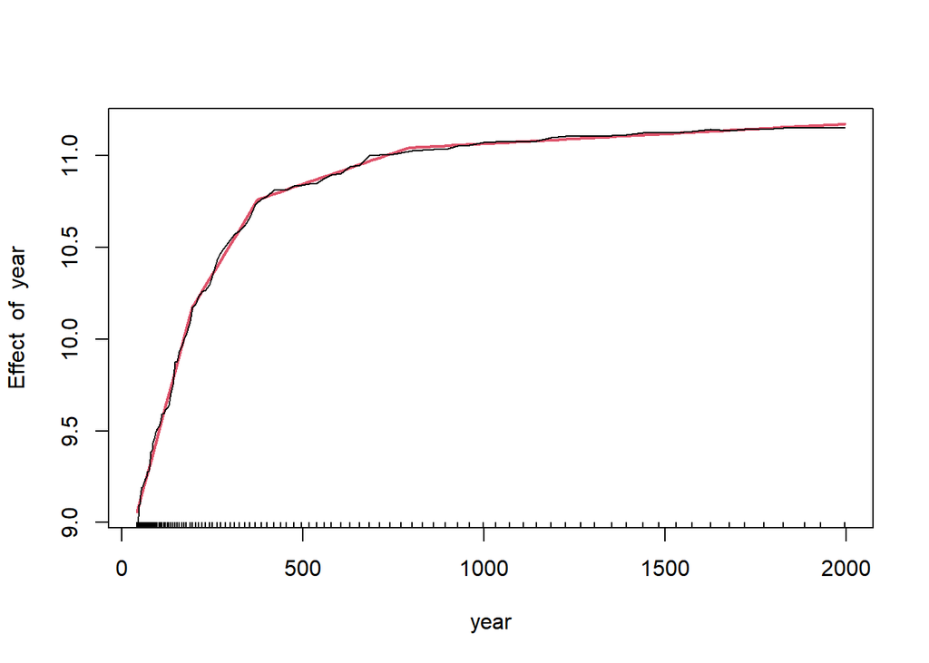

```r
plot(Ne_median.seg)
lines(tmp$year, log(tmp$Ne_median))
```

## c) Range between 2000 - 15000 years

Filter and resample data for period

```r
tmax <- 15000
period = c(max(Models[[2]]$psi[,2]), tmax)
size = 100 # desired size of subsample
tmp  = Ne_data %>% filter(year < period[2], year > period[1])
factor <- nrow(tmp) %/% size
tmp  = tmp[c(1:nrow(tmp)) %% factor == 0,]
dim(tmp)
```

```
## [1] 100   6
```

```r
Ne_median.lm <- lm(log(Ne_median) ~ year, data = tmp)
Ne_median.seg <- segmented(Ne_median.lm,
                    seg.Z = ~ year,
                    psi = list(year = breakpoints[breakpoints > period[1] & breakpoints < period[2]]))
Models[[3]] <- Ne_median.seg
```

```r
summary(Ne_median.seg)
```

```
##
##  ***Regression Model with Segmented Relationship(s)***
##
## Call:
## segmented.lm(obj = Ne_median.lm, seg.Z = ~year, psi = list(year = breakpoints[breakpoints >
##     period[1] & breakpoints < period[2]]))
##
## Estimated Break-Point(s):
##                Est.  St.Err
## psi1.year 2158.419 112.620
## psi2.year 7748.809  93.089
##
## Meaningful coefficients of the linear terms:
##               Estimate Std. Error t value Pr(>|t|)
## (Intercept)  1.097e+01  1.887e-02 581.261  < 2e-16 ***
## year         9.834e-05  1.287e-05   7.642 1.79e-11 ***
## U1.year     -1.125e-04  1.307e-05  -8.610       NA
## U2.year     -1.218e-04  3.049e-06 -39.932       NA
## ---
## Signif. codes:  0 '***' 0.001 '**' 0.01 '*' 0.05 '.' 0.1 ' ' 1
##
## Residual standard error: 0.02417 on 94 degrees of freedom
## Multiple R-Squared: 0.993,  Adjusted R-squared: 0.9926
##
## Boot restarting based on 7 samples. Last fit:
## Convergence attained in 5 iterations (rel. change 2.3102e-12)
```

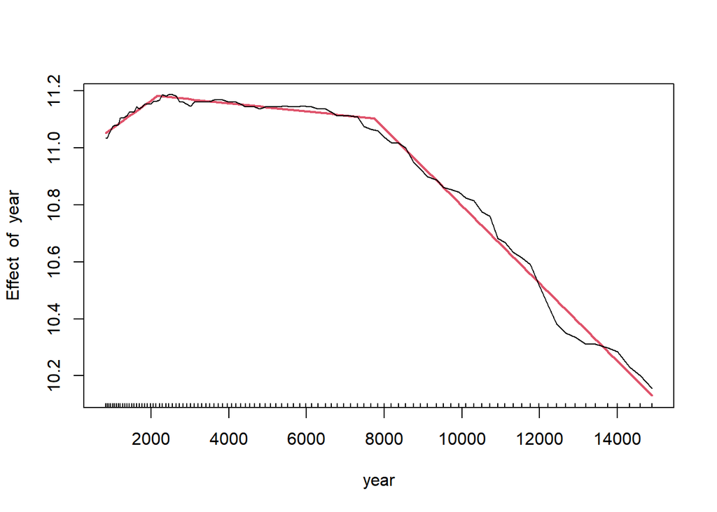

```r
plot(Ne_median.seg)
lines(tmp$year, log(tmp$Ne_median))
```

# 4. Summarize results

## a) Fitted breakpoints

```r
Breakpoints <- lapply(1:length(Models), function(i)
  data.frame(Model=i, Models[[i]]$psi))
for(i in 1:length(Breakpoints))
{
  row.names(Breakpoints[[i]]) <- paste("Model", i, "psi", 1:nrow(Breakpoints[[i]]))
}
Breakpoints <- data.frame(Reduce(rbind, Breakpoints))
Breakpoints$Initial <- breakpoints[breakpoints < tmax]

Breakpoints
```

```
##               Model Initial        Est.       St.Err
## Model 1 psi 1     1       2    2.120245   0.02712032
## Model 1 psi 2     1      10    8.854784   0.12953821
## Model 1 psi 3     1      40   41.318509   0.84536594
## Model 2 psi 1     2     200  195.658322   4.42567970
## Model 2 psi 2     2     400  375.771402   7.92617832
## Model 2 psi 3     2     700  790.126945  31.36676625
## Model 3 psi 1     3    2000 2158.419458 112.61982572
## Model 3 psi 2     3    8000 7748.808688  93.08902050
```

## b) Estimated rates of change

```r
Rates <- lapply(1:length(Models), function(i) slope(Models[[i]])$year)
for(i in 1:length(Rates))
{
  row.names(Rates[[i]]) <- paste("Model", i, row.names(Rates[[i]]))
  if(i < length(Rates)) {Rates[[i]] = Rates[[i]][1:(nrow(Rates[[i]])-1),]}
}
Rates <- data.frame(Reduce(rbind, Rates))
Rates$lower.t <- c(1, signif(Breakpoints$'Est.',2))
Rates$upper.t <- c(signif(Breakpoints$'Est.',2), tmax)
Rates$rate.est <- -1 * (exp(Rates$Est) - 1)

Rates
```

```
##                       Est.    St.Err.  t.value   CI.95...l   CI.95...u lower.t
## Model 1 slope1  1.0209e+00 2.3993e-02  42.5520  9.7329e-01  1.0686e+00     1.0
## Model 1 slope2  2.3688e-01 4.0812e-03  58.0430  2.2878e-01  2.4499e-01     2.1
## Model 1 slope3  4.7954e-02 1.0020e-03  47.8570  4.5963e-02  4.9944e-02     8.9
## Model 2 slope1  7.3150e-03 1.0369e-04  70.5440  7.1091e-03  7.5209e-03    41.0
## Model 2 slope2  3.2465e-03 1.4632e-04  22.1870  2.9559e-03  3.5371e-03   200.0
## Model 2 slope3  6.7977e-04 5.8072e-05  11.7060  5.6445e-04  7.9509e-04   380.0
## Model 3 slope1  9.8343e-05 1.2869e-05   7.6417  7.2791e-05  1.2390e-04   790.0
## Model 3 slope2 -1.4164e-05 2.2657e-06  -6.2514 -1.8663e-05 -9.6652e-06  2200.0
## Model 3 slope3 -1.3593e-04 2.0408e-06 -66.6060 -1.3998e-04 -1.3188e-04  7700.0
##                upper.t      rate.est
## Model 1 slope1     2.1 -1.775692e+00
## Model 1 slope2     8.9 -2.672890e-01
## Model 1 slope3    41.0 -4.912239e-02
## Model 2 slope1   200.0 -7.341820e-03
## Model 2 slope2   380.0 -3.251776e-03
## Model 2 slope3   790.0 -6.800011e-04
## Model 3 slope1  2200.0 -9.834784e-05
## Model 3 slope2  7700.0  1.416390e-05
## Model 3 slope3 15000.0  1.359208e-04
```

# 5. Fit single model with all breakpoints

## a) Combine resampled data

```r
tmp <- data.frame(Reduce(rbind, lapply(Models,
                   function(mod) mod$model[,c("year", "log(Ne_median)")])))
names(tmp) <- c("year", "log(Ne_median)")
tmp$Ne_median <- exp(tmp$"log(Ne_median)")
dim(tmp)
```

```
## [1] 301   3
```

## b) Fit piecewise regression model

```r
Ne_median.lm <- lm(log(Ne_median) ~ year, data = tmp)
Ne_median.seg <- segmented(Ne_median.lm,
                    seg.Z = ~ year,
                    psi = list(year = Breakpoints$Est))
```

```r
summary(Ne_median.seg)
```

```
##
##  ***Regression Model with Segmented Relationship(s)***
##
## Call:
## segmented.lm(obj = Ne_median.lm, seg.Z = ~year, psi = list(year = Breakpoints$Est))
##
## Estimated Break-Point(s):
##                Est.  St.Err
## psi1.year    2.120   0.021
## psi2.year    8.855   0.100
## psi3.year   42.398   0.494
## psi4.year  193.671   4.838
## psi5.year  375.724   9.048
## psi6.year  792.321  34.099
## psi7.year 2094.484 116.669
## psi8.year 7742.118 127.985
##
## Meaningful coefficients of the linear terms:
##               Estimate Std. Error t value Pr(>|t|)
## (Intercept)  3.684e+00  2.766e-02 133.198   <2e-16 ***
## year         1.021e+00  1.855e-02  55.049   <2e-16 ***
## U1.year     -7.841e-01  1.881e-02 -41.678       NA
## U2.year     -1.889e-01  3.248e-03 -58.160       NA
## U3.year     -4.057e-02  7.836e-04 -51.775       NA
## U4.year     -4.136e-03  1.967e-04 -21.026       NA
## U5.year     -2.569e-03  1.709e-04 -15.031       NA
## U6.year     -5.745e-04  6.869e-05  -8.363       NA
## U7.year     -1.191e-04  1.331e-05  -8.950       NA
## U8.year     -1.222e-04  4.167e-06 -29.312       NA
## ---
## Signif. codes:  0 '***' 0.001 '**' 0.01 '*' 0.05 '.' 0.1 ' ' 1
##
## Residual standard error: 0.03348 on 283 degrees of freedom
## Multiple R-Squared: 0.9998,  Adjusted R-squared: 0.9998
##
## Boot restarting based on 6 samples. Last fit:
## Convergence attained in 3 iterations (rel. change 9.6906e-12)
```

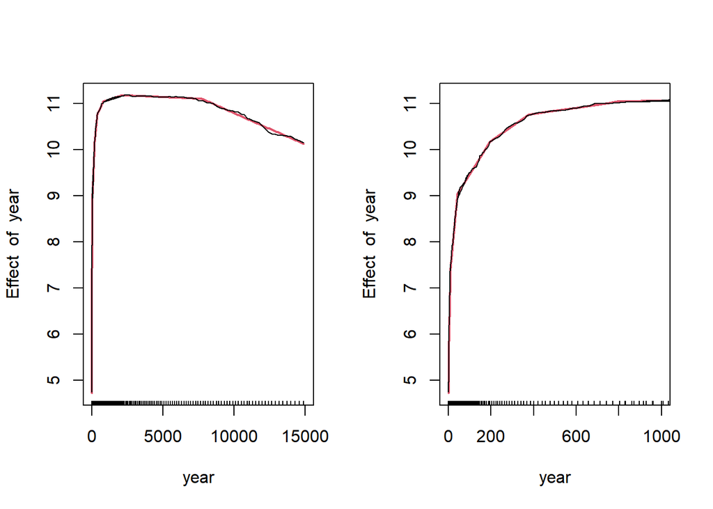

```r
# first, show figures
par(mfrow = c(1, 2))

plot(Ne_median.seg, xlim=c(0, tmax))
lines(tmp$year, log(tmp$Ne_median))

plot(Ne_median.seg, xlim=c(0, 1000))
lines(tmp$year, log(tmp$Ne_median))
```

```r
# save figures
png(filename = here::here("./Figures_Tables/Stairway_plot/mu_1.8e-8/gen_time_2yr/breakpoint_figure.png"),
    width = 10,
    height = 4,
    units = "in",
    res = 500)

par(mfrow = c(1, 2))

# entire plot
plot(Ne_median.seg,
     xlim=c(0, tmax),
     ylim = c(4, 12),
     col = "brown1",
     lwd = 2)
lines(tmp$year,
      log(tmp$Ne_median),
     col = "black",
     lwd = 1,
     lty = 2)
legend(x = "bottomright",
       legend = c("Linear model",
                  "Piecewise model"),
       col = c("black",
               "brown1"),
       lwd = c(1,2),
       lty = c(2,1),
       bty = "n",
       cex = 0.8)

# inset of 1000 years
plot(Ne_median.seg,
     xlim=c(0, 1000),
          ylim = c(4, 12),
          col = "brown1",
     lwd = 2)
lines(tmp$year,
      log(tmp$Ne_median),
           col = "black",
     lwd = 1,
     lty = 2)
legend(x = "bottomright",
       legend = c("Linear model",
                  "Piecewise model"),
       col = c("black",
               "brown1"),
       lwd = c(1,2),
       lty = c(2,1),
       bty = "n",
       cex = 0.8)

dev.off()
```

## c) Convert years ago to calendar years and slope estimates to population growth rates forward in time

```r
Breakpoints_all <- data.frame(Ne_median.seg$psi) %>% mutate(Initial =  Breakpoints$Est)
Breakpoints_all
```

```
##               Initial        Est.       St.Err
## psi1.year    2.120245    2.120245   0.02096378
## psi2.year    8.854784    8.854784   0.10013194
## psi3.year   41.318509   42.398358   0.49389891
## psi4.year  195.658322  193.670709   4.83755503
## psi5.year  375.771402  375.724155   9.04843073
## psi6.year  790.126945  792.321141  34.09851603
## psi7.year 2158.419458 2094.484174 116.66940498
## psi8.year 7748.808688 7742.118476 127.98476431
```

```r
Year0 <- 2019
Rates_all <- data.frame(slope(Ne_median.seg)$year)
Rates_all$rate.est <- -1 * (exp(Rates_all$Est) - 1)
Rates_all$lower.t <- c(1, Breakpoints_all$'Est.')
Rates_all$upper.t <- c(Breakpoints_all$'Est.', tmax)
Rates_all$rate.CI.95.l <-  -1 * (exp(Rates_all$CI.95...l) - 1)
Rates_all$rate.CI.95.u <-  -1 * (exp(Rates_all$CI.95...u) - 1)
full_table <- Rates_all %>% mutate(rate.est =round(rate.est, 5),
                     rate.CI.95.l =round(rate.CI.95.l, 5),
                     rate.CI.95.u =round(rate.CI.95.u, 5)) %>%
              mutate(year.u = Year0 - round(lower.t),
                     year.l = Year0 - round(upper.t)) %>%
              dplyr::select( year.l, year.u, rate.est, rate.CI.95.l, rate.CI.95.u)
full_table
```

```
##        year.l year.u rate.est rate.CI.95.l rate.CI.95.u
## slope1   2017   2018 -1.77569     -1.67629     -1.87888
## slope2   2010   2017 -0.26729     -0.25944     -0.27518
## slope3   1977   2010 -0.04912     -0.04752     -0.05072
## slope4   1825   1977 -0.00741     -0.00718     -0.00765
## slope5   1643   1825 -0.00325     -0.00294     -0.00356
## slope6   1227   1643 -0.00068     -0.00055     -0.00081
## slope7    -75   1227 -0.00011     -0.00008     -0.00013
## slope8  -5723    -75  0.00001      0.00002      0.00001
## slope9 -12981  -5723  0.00014      0.00014      0.00013
```

Here, each period is defined by its beginning (year.l) and end (year.u) in calendar years, and the estimate of the population growth rate (rate.est) is given with the lower and upper limits of a 95% confidence interval.

```r
# export table

write.csv(full_table,
          here::here("./Figures_Tables/Stairway_plot/mu_1.8e-8/gen_time_2yr/breakpoint_table.csv"))
```